# Marketing_Bank_Arbre_de_decision

Losséni SANGARE

2023-12-13

# ARBRE DE DECISION

```r
options(repos = c(CRAN = "https://cran.r-project.org"))# pour permettre l'execution du fichier r-markdown (Knit)
```

```r
rm(list=ls())
```

## Chargement des fichiers

```r
souscription <- read.csv("D:/UTT/PROGRAMATION R/Data/Souscription.csv", sep=";")
View(souscription)
```

## Convertir toutes les variables en facteurs

```r
colonnes_catégorielles <- c("job", "marital", "education", "default","housing","loan","contact","month","day_of_week","poutcome","y")

# Convertir les variables catégorielles en facteurs avec lapply
souscription[colonnes_catégorielles] <- lapply(souscription[colonnes_catégorielles], as.factor)
```

## Importation de la librairie de, l’arbre de decision

```r
#install.packages("dplyr")
library(dplyr)
#install.packages("rpart")
library(rpart)
```

## les données en ensembles d’entraînement (70%) et de test (30%)

```r
  set.seed(1234)  # Pour la reproductibilité
  indices <- sample(1:nrow(souscription), size = 0.7 * nrow(souscription))
  train_data <- souscription[indices, ]
  test_data <- souscription[-indices, ]
```

## sauvegarde et suppression de la cible y des donnée de test

```r
#cible_test = test_data$y
#test_data = test_data[,-ncol(test_data)]
```

## Modelisation par l’arbre de decision de la variable dependante y en fonction des autres variable

```r
arbre = rpart(y~.,data = train_data, cp=0.03)
arbre
```

```
## n= 2883
##
## node), split, n, loss, yval, (yprob)
##       * denotes terminal node
##
##  1) root 2883 324 no (0.88761707 0.11238293)
##    2) nr.employed>=5087.65 2508 154 no (0.93859649 0.06140351)
##      4) duration< 567.5 2284  56 no (0.97548161 0.02451839) *
##      5) duration>=567.5 224  98 no (0.56250000 0.43750000)
##       10) duration< 838.5 139  44 no (0.68345324 0.31654676) *
##       11) duration>=838.5 85  31 yes (0.36470588 0.63529412) *
##    3) nr.employed< 5087.65 375 170 no (0.54666667 0.45333333)
##      6) duration< 165.5 131  24 no (0.81679389 0.18320611) *
##      7) duration>=165.5 244  98 yes (0.40163934 0.59836066) *
```

## affichage de l’arbre produit sur notre jeu de données d’entrainement

pour cela nous avons besoin d’importer le module plot de la librairie rpart que nous venons de charger

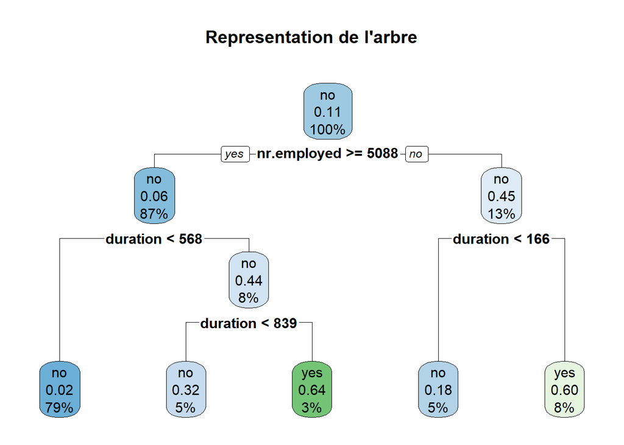

```r
install.packages("rpart.plot")
library("rpart.plot")
rpart.plot(arbre,main="Representation de l'arbre")
```

## prediction sur les données de test

```r
pred = predict(arbre, newdata=test_data, type = 'class')
```

## comparaison de la prédiction par rapport aux vrai valeur y de l’ensemble de test

```r
mean(pred == test_data$y)
```

```
## [1] 0.9158576
```

```r
table(pred, test_data$y)
```

```
##
## pred    no  yes
##   no  1056   51
##   yes   53   76
```

#choix du meilleur cout de complexité par validation croisé

```r
grille_cp = data.frame(cp= seq(0.01, 0.1, by = 0.01))
library(caret)
```

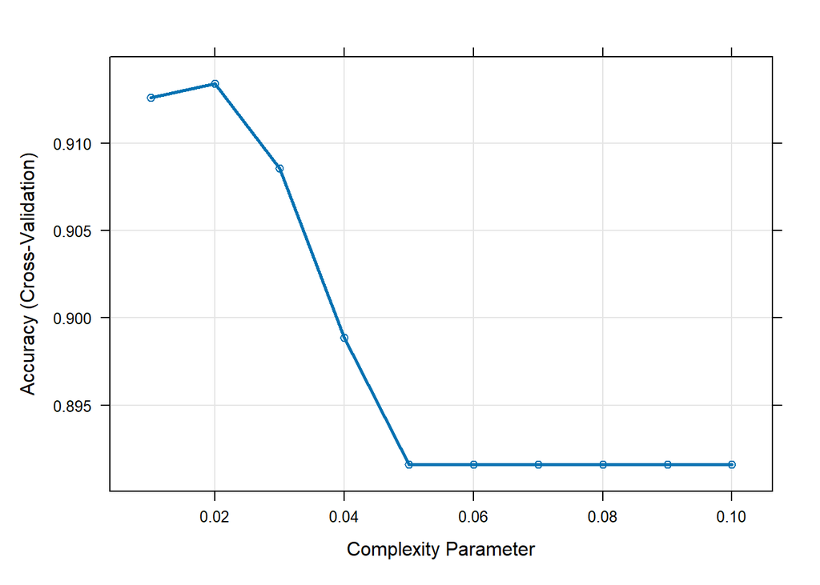

```r
ctrl = trainControl(method = "cv",index = list(1:dim(train_data)[1])) # method="cv" pour validation croisé
sel_cp = train(y ~ ., data = souscription, method = "rpart", trControl = ctrl, tuneGrid = grille_cp)
plot(sel_cp,lwd=2.5)
```

```r
sel_cp
```

```
## CART
##
## 4119 samples
##   20 predictor
##    2 classes: 'no', 'yes'
##
## No pre-processing
## Resampling: Cross-Validated (10 fold)
## Summary of sample sizes: 2883
## Resampling results across tuning parameters:
##
##   cp    Accuracy   Kappa
##   0.01  0.9126214  0.5509567
##   0.02  0.9134304  0.4941711
##   0.03  0.9085761  0.3990603
##   0.04  0.8988673  0.2614158
##   0.05  0.8915858  0.0000000
##   0.06  0.8915858  0.0000000
##   0.07  0.8915858  0.0000000
##   0.08  0.8915858  0.0000000
##   0.09  0.8915858  0.0000000
##   0.10  0.8915858  0.0000000
##
## Accuracy was used to select the optimal model using the largest value.
## The final value used for the model was cp = 0.02.
```

## Ajustement du model

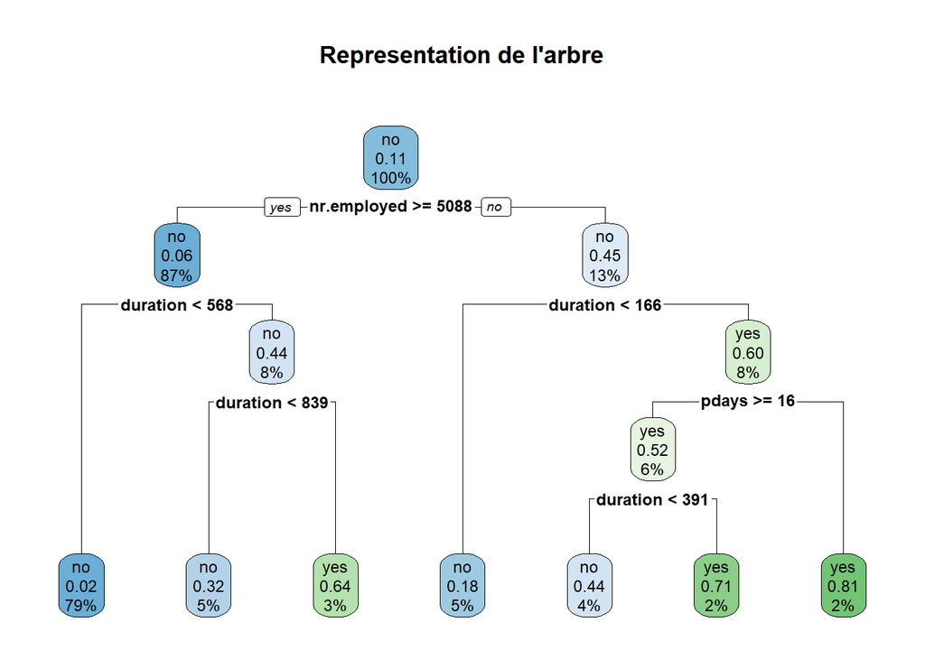

```r
arbre = rpart(y~.,data = train_data, cp=0.02)
rpart.plot(arbre,main="Representation de l'arbre")
```

```r
pred = predict(arbre, newdata=test_data, type = 'class')
mean(pred == test_data$y)
```

```
## [1] 0.9255663
```

```r
table(pred, test_data$y)
```

```
##
## pred    no  yes
##   no  1084   67
##   yes   25   60
```

Après ajustement du model, la methode CART nous donne une precision de 92,55% sur les données de test . la Matrice de confusion nous donne comme détail 1084 vrai négatif (y == “no” et la prediction a donnée “no”), et 60 vrai positif((y == “yes” et la prediction a donnée “yes”)